# Intro to DS - LM part II factor regressors

Edwin Lo, GWU Intro to Data Science DATS 6101

2022-03-31

# HW assignment

## Linear model - categorical regressors

Let us re-analyze the problem we had from last time, but include categorical regressors. First, import the data, and change those appropriate ones to factors.

```r
bikeorig = data.frame(read.csv("bikedata.csv"))
bike = subset(bikeorig, select = -c(Date, Casual.Users, Registered.Users)) # remove irrelevant columns
colnames(bike)[4:11] = c("Day","Workday","Weather","TempF","TempxFF","Humidity","Wind","Tusers") # rename some columns
bike16 = subset(bike, bike$Hour == 16) # with only Hour-16 data. All columns are numerical
nrow(bike16)
bike16$Hour = NULL # Hour has only one value '16' now. No need to keep this column.
bike16$TempxFF = NULL
bike_final = bike16
bike_final$Season = factor(bike16$Season)
bike_final$Holiday = factor(bike16$Holiday)
bike_final$Day = factor(bike16$Day)
bike_final$Workday = factor(bike16$Workday)
bike_final$Weather = factor(bike16$Weather)
str(bike_final) # Same as bike16 except some columns are now factor level.
```

### Question 0

**Pearson vs Spearman**  
Read the article here:  
Hauke,J. & Kossowski,T.(2011). [Comparison of Values of Pearson’s and Spearman’s Correlation Coefficients on the Same Sets of Data. Quaestiones Geographicae, 30(2) 87-93](https://doi.org/10.2478/v10117-011-0021-1).  
Simply indicate you have read it.

I read the article and understood that Spearman correlation is based on rank statistic and is primarily used when:

1. Assumption of the normality does not necessarily need to be made
2. You want a monotonic function to describe the relationship between the two variables rather just a linear function
3. Qualitative variables required to be assessed

### Question 1

**Compare the difference of the correlation matrix between the Pearson and Spearman methods**  
Look at the correlation matrices using the two methods. Compare and comment on their differences.

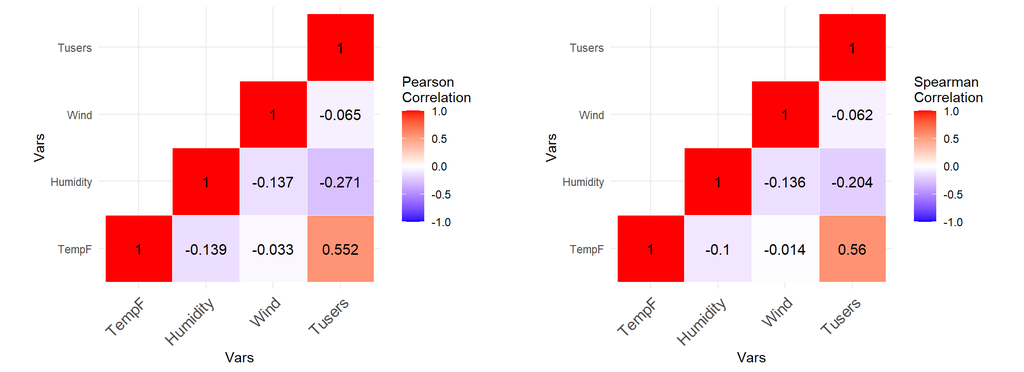

```r
num_cnames <- NULL
for(cname in colnames(bike_final))
{
  if(class(bike_final[, cname]) != "factor")
  {
    num_cnames <- c(num_cnames, cname)
  }
}

pearson <- cor(bike_final[, num_cnames])
spearman <- cor(bike_final[, num_cnames], method = 'spearman')

pearson[lower.tri(pearson)] <- NA
spearman[lower.tri(spearman)] <- NA


library(reshape2)
pearson <- melt(pearson, na.rm=T)
spearman <- melt(spearman, na.rm=T)

# Heatmap
library(ggplot2)
p <- ggplot(data = pearson, aes(Var2, Var1, fill = value))+
     geom_tile(color = "white")+
     xlab('Vars')+
     ylab('Vars')+
     geom_text(aes(Var2, Var1, label = round(value, 3)), color = "black", size = 4) +
     scale_fill_gradient2(low = "blue", high = "red", mid = "white",
       midpoint = 0, limit = c(-1,1), space = "Lab",
       name="Pearson\nCorrelation") +
      theme_minimal()+
     theme(axis.text.x = element_text(angle = 45, vjust = 1,
        size = 12, hjust = 1))+
     coord_fixed()

s <- ggplot(data = spearman, aes(Var2, Var1, fill = value))+
     geom_tile(color = "white")+
     xlab('Vars')+
     ylab('Vars')+
     geom_text(aes(Var2, Var1, label = round(value, 3)), color = "black", size = 4) +
     scale_fill_gradient2(low = "blue", high = "red", mid = "white",
       midpoint = 0, limit = c(-1,1), space = "Lab",
       name="Spearman\nCorrelation") +
      theme_minimal()+
     theme(axis.text.x = element_text(angle = 45, vjust = 1,
        size = 12, hjust = 1))+
     coord_fixed()

grid.arrange(p, s, nrow=1)
```

Spearman is a modified version of Pearson correlation that converts the data into rank to estimate how well a monotonic function can describe the relationship between two variables, as per the paper by Hauke et.al. For instance, let me first convert Humidity and TempF to rank so that we can then use Pearson to compute the correlation to compare.

```r
humidity <- rank(bike_final$Humidity)
temp <- rank(bike_final$TempF)
cor(data.frame(Humidity=humidity, TempF=temp))
```

```
##          Humidity   TempF
## Humidity   1.0000 -0.0999
## TempF     -0.0999  1.0000
```

I can clearly see the above result is consistent with the Spearman correlation plot.

### Question 2

**Build a baseline linear model for `Tusers`, with one numerical predictor.**  
Write down the model equation as we did in class, like  
`Tusers` = 0.28 + 5.29 `TempF`, just as an example.

```r
model1 <- lm(Tusers~TempF, data=bike_final)
summary(model1)
```

```
##
## Call:
## lm(formula = Tusers ~ TempF, data = bike_final)
##
## Residuals:
##    Min     1Q Median     3Q    Max
## -319.1  -90.9   -5.1   77.1  431.6
##
## Coefficients:
##             Estimate Std. Error t value Pr(>|t|)
## (Intercept)   -0.154     18.079   -0.01     0.99
## TempF          4.828      0.270   17.85   <2e-16 ***
## ---
## Signif. codes:  0 '***' 0.001 '**' 0.01 '*' 0.05 '.' 0.1 ' ' 1
##
## Residual standard error: 124 on 728 degrees of freedom
## Multiple R-squared:  0.304,  Adjusted R-squared:  0.303
## F-statistic:  319 on 1 and 728 DF,  p-value: <2e-16
```

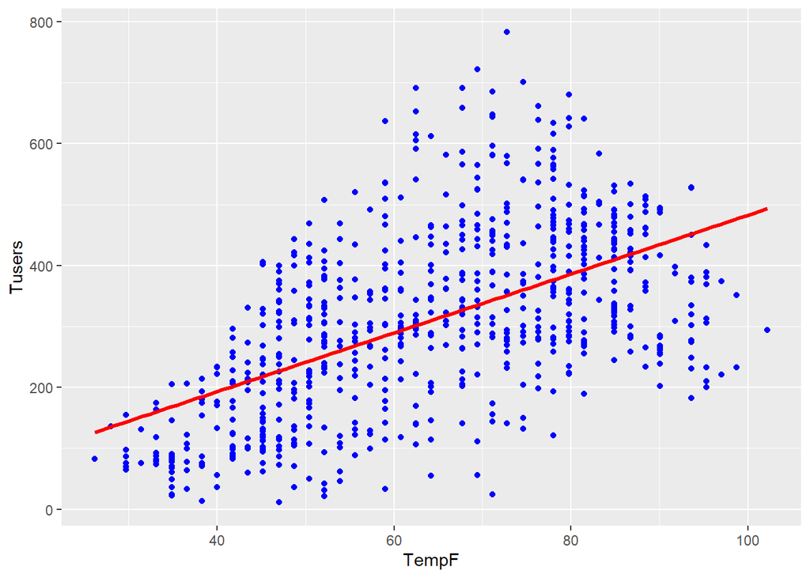

```r
Tusers <- -0.154 + 4.828 * bike_final$TempF

temp <- seq(min(bike_final$TempF), max(bike_final$TempF), length.out=100)
df2 <- data.frame(TempF=temp)
Tusers <- predict.lm(model1, df2)
df2 <- data.frame(TempF=temp, Tusers=Tusers)
ggplot(bike_final, aes(x=TempF, y=Tusers)) +
geom_point(color='blue') +
geom_line(data=df2, color='red', lwd=1.1)
```

`Tusers` = - 0.154 + 4.828 `TempF`

### Question 3

**Build a linear model for `Tusers`, with one numerical and one categorical predictor with at least 3 levels.**  
Use the correlation matrix as a guide to decide on which variables to use. Find and interpret the results. Also write down the model equation for the different categorical factor levels on separate lines.

In order to build a linear model with one numerical and a categorical variable with correlation into account, I believe it would be appropriate to first look at the correlation between all variables including numerical and categorical by converting all of them into rank order.

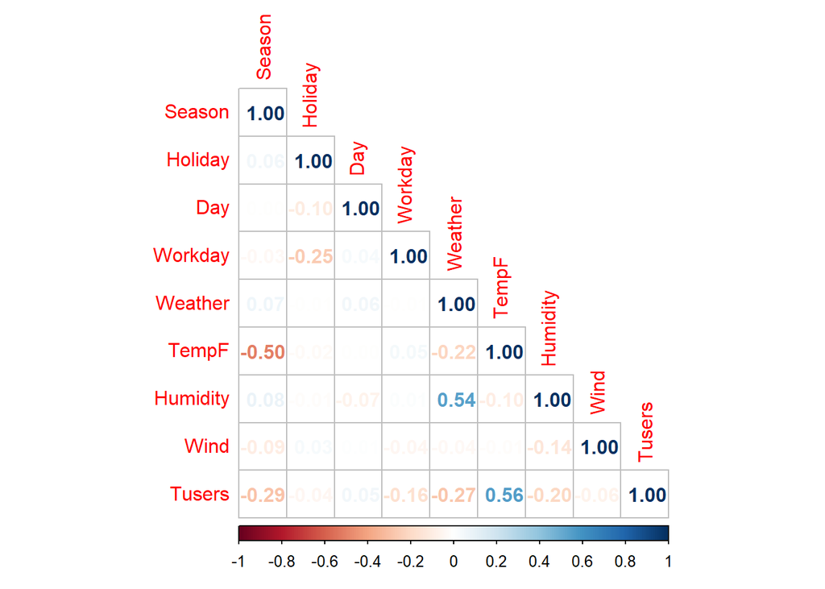

```r
bike_final2 <- bike_final
bike_final2$Season <- rank(bike_final2$Season)
bike_final2$Holiday <- rank(bike_final2$Holiday)
bike_final2$Day <- rank(bike_final2$Day)
bike_final2$Workday <- rank(bike_final2$Workday)
bike_final2$Weather <- rank(bike_final2$Weather)
bike_final2$TempF <- rank(bike_final2$TempF)
bike_final2$Humidity <- rank(bike_final2$Humidity)
bike_final2$Wind <- rank(bike_final2$Wind)
bike_final2$Tusers <- rank(bike_final2$Tusers)

corrplot::corrplot(cor(bike_final2),
                   method='number',
                   type='lower')
```

I think we are now in a good shape to create a linear model with one continuous and a categorical variable with at least 3 levels. The categorical variable that is next highly correlated with Tusers would be Season (with 4 levels).

```r
model2 <- lm(Tusers~TempF+Season, data=bike_final)
summary(model2)
```

```
##
## Call:
## lm(formula = Tusers ~ TempF + Season, data = bike_final)
##
## Residuals:
##    Min     1Q Median     3Q    Max
## -345.3  -82.3   -3.3   74.4  362.8
##
## Coefficients:
##             Estimate Std. Error t value Pr(>|t|)
## (Intercept)  -45.197     29.606   -1.53  0.12730
## TempF          5.576      0.437   12.77  < 2e-16 ***
## Season2      -55.725     14.950   -3.73  0.00021 ***
## Season3       59.523     12.352    4.82  1.8e-06 ***
## Season4      -16.011     14.944   -1.07  0.28436
## ---
## Signif. codes:  0 '***' 0.001 '**' 0.01 '*' 0.05 '.' 0.1 ' ' 1
##
## Residual standard error: 118 on 725 degrees of freedom
## Multiple R-squared:  0.375,  Adjusted R-squared:  0.371
## F-statistic:  109 on 4 and 725 DF,  p-value: <2e-16
```

```r
s2_b <- bike_final$Season == 2
s3_b <- bike_final$Season == 3
s4_b <- bike_final$Season == 4

tusers <- -45.197 + 5.576*bike_final$TempF - 55.725*bike_final$s2_b + 59.523*bike_final$s3_b -16.011*bike_final$s4_b
```

Since season is a categorial variable with 4 levels, 3=n.levels-1 coefficients are used along with TempF to make the final prediction. If Season2, Season3 and Season4 all are False, then it is assumed that Season1 must be activated and this is adjusted in the Intercept term.

If Season1 then `Tusers` = -45.197 + 5.576 `TempF`  
Season2 then `Tusers` = -45.197 + 5.576 `TempF` - 55.725 `Season2` Season3 then `Tusers` = -45.197 + 5.576 `TempF` + 59.523 `Season3` Season4 then `Tusers` = -45.197 + 5.576 `TempF` - 16.011 `Season4`

### Question 4

**Next extend the previous model for `Tusers`, but include the interaction term between the numerical and categorical variable.**  
Again, write down the model equation for different categorical factor levels on separate lines. Comment of the slope and coefficients.

“But” in the line - extend the model “but” include the interaction…, is slightly confusing.  
Again, “slope and coefficients” ? You mean bias/intercept and coefficients/slopes ?

```r
model3 <- lm(Tusers~TempF+Season+TempF:Day, data=bike_final)
summary(model3)
```

```
##
## Call:
## lm(formula = Tusers ~ TempF + Season + TempF:Day, data = bike_final)
##
## Residuals:
##    Min     1Q Median     3Q    Max
## -365.8  -77.6   -8.2   81.9  291.4
##
## Coefficients:
##             Estimate Std. Error t value Pr(>|t|)
## (Intercept)  -59.437     27.960   -2.13    0.034 *
## TempF          6.575      0.446   14.75  < 2e-16 ***
## Season2      -60.758     14.109   -4.31  1.9e-05 ***
## Season3       59.037     11.648    5.07  5.1e-07 ***
## Season4      -12.502     14.097   -0.89    0.375
## TempF:Day1    -1.177      0.232   -5.07  5.2e-07 ***
## TempF:Day2    -1.211      0.231   -5.24  2.1e-07 ***
## TempF:Day3    -1.412      0.231   -6.11  1.6e-09 ***
## TempF:Day4    -1.254      0.231   -5.43  7.8e-08 ***
## TempF:Day5    -0.491      0.232   -2.12    0.035 *
## TempF:Day6     0.184      0.233    0.79    0.430
## ---
## Signif. codes:  0 '***' 0.001 '**' 0.01 '*' 0.05 '.' 0.1 ' ' 1
##
## Residual standard error: 111 on 719 degrees of freedom
## Multiple R-squared:  0.449,  Adjusted R-squared:  0.441
## F-statistic: 58.5 on 10 and 719 DF,  p-value: <2e-16
```

If Day0 and  
Season1 then `Tusers` = -59.437 + 6.575 `TempF` Season2 then `Tusers` = -59.437 + 6.575 `TempF` - 60.758 `Season2` Season3 then `Tusers` = -59.437 + 6.575 `TempF` + 59.037 `Season3` Season4 then `Tusers` = -59.437 + 6.575 `TempF` - 12.502 `Season4`

If Day1 and  
Season1 then `Tusers` = -59.437 + 6.575 `TempF` - 1.177 `TempF``Day1`  
Season2 then `Tusers` = -59.437 + 6.575 `TempF` - 60.758 `Season2` - 1.177 `TempF``Day1`  
Season3 then `Tusers` = -59.437 + 6.575 `TempF` + 59.037 `Season3` - 1.177 `TempF``Day1`  
Season4 then `Tusers` = -59.437 + 6.575 `TempF` - 12.502 `Season4` - 1.177 `TempF``Day1`

If Day2 and  
Season1 then `Tusers` = -59.437 + 6.575 `TempF` - 1.211 `TempF``Day2`  
Season2 then `Tusers` = -59.437 + 6.575 `TempF` - 60.758 `Season2` - 1.211 `TempF``Day2`  
Season3 then `Tusers` = -59.437 + 6.575 `TempF` + 59.037 `Season3` - 1.211 `TempF``Day2`  
Season4 then `Tusers` = -59.437 + 6.575 `TempF` - 12.502 `Season4` - 1.211 `TempF``Day2`

If Day3 and  
Season1 then `Tusers` = -59.437 + 6.575 `TempF` - 1.412 `TempF``Day3`  
Season2 then `Tusers` = -59.437 + 6.575 `TempF` - 60.758 `Season2` - 1.412 `TempF``Day3`  
Season3 then `Tusers` = -59.437 + 6.575 `TempF` + 59.037 `Season3` - 1.412 `TempF``Day3`  
Season4 then `Tusers` = -59.437 + 6.575 `TempF` - 12.502 `Season4` - 1.412 `TempF``Day3`

If Day4 and  
Season1 then `Tusers` = -59.437 + 6.575 `TempF` - 1.254 `TempF``Day4`  
Season2 then `Tusers` = -59.437 + 6.575 `TempF` - 60.758 `Season2` - 1.254 `TempF``Day4`  
Season3 then `Tusers` = -59.437 + 6.575 `TempF` + 59.037 `Season3` - 1.254 `TempF``Day4`  
Season4 then `Tusers` = -59.437 + 6.575 `TempF` - 12.502 `Season4` - 1.254 `TempF``Day4`

If Day5 and  
Season1 then `Tusers` = -59.437 + 6.575 `TempF` - 0.491 `TempF``Day5`  
Season2 then `Tusers` = -59.437 + 6.575 `TempF` - 60.758 `Season2` - 0.491 `TempF``Day5`  
Season3 then `Tusers` = -59.437 + 6.575 `TempF` + 59.037 `Season3` - 0.491 `TempF``Day5`  
Season4 then `Tusers` = -59.437 + 6.575 `TempF` - 12.502 `Season4` - 0.491 `TempF``Day5`

### Question 5

**Let us use this model equation `Tusers ~ TempF + Season + Wind:Weather + Season:Weather`.**  
Notice the presence/absence of coefficients for the base-level categories. No need to write down the model equations this time. But comment on what is the difference between how the base-level is handled here and the previous models.

```r
tmp_model <- lm(Tusers ~ TempF + Season + Wind:Weather + Season:Weather, data=bike_final)
summary(tmp_model)
```

```
##
## Call:
## lm(formula = Tusers ~ TempF + Season + Wind:Weather + Season:Weather,
##     data = bike_final)
##
## Residuals:
##    Min     1Q Median     3Q    Max
## -303.2  -80.5   -8.0   67.1  381.8
##
## Coefficients: (3 not defined because of singularities)
##                  Estimate Std. Error t value Pr(>|t|)
## (Intercept)         1.546     30.550    0.05  0.95967
## TempF               5.005      0.428   11.69  < 2e-16 ***
## Season2           -57.211     15.529   -3.68  0.00025 ***
## Season3            76.316     13.854    5.51  5.1e-08 ***
## Season4           -25.146     16.256   -1.55  0.12233
## Wind:Weather1       0.113      0.552    0.21  0.83751
## Wind:Weather2      -1.219      0.909   -1.34  0.18066
## Wind:Weather3      -4.431      1.238   -3.58  0.00037 ***
## Wind:Weather4      -5.230      5.158   -1.01  0.31092
## Season2:Weather2   71.773     28.665    2.50  0.01251 *
## Season3:Weather2  -22.671     23.341   -0.97  0.33174
## Season4:Weather2   12.424     23.834    0.52  0.60235
## Season2:Weather3   21.840     39.968    0.55  0.58493
## Season3:Weather3 -110.515     33.375   -3.31  0.00098 ***
## Season4:Weather3  -38.063     33.201   -1.15  0.25198
## Season2:Weather4       NA         NA      NA       NA
## Season3:Weather4       NA         NA      NA       NA
## Season4:Weather4       NA         NA      NA       NA
## ---
## Signif. codes:  0 '***' 0.001 '**' 0.01 '*' 0.05 '.' 0.1 ' ' 1
##
## Residual standard error: 112 on 715 degrees of freedom
## Multiple R-squared:  0.439,  Adjusted R-squared:  0.428
## F-statistic: 39.9 on 14 and 715 DF,  p-value: <2e-16
```

### Question 6

**Compare the above models using ANOVA**  
Interpret and comment on your results.

```r
anova.model <- anova(model1, model2, model3)
anova.model
```

```
## Analysis of Variance Table
##
## Model 1: Tusers ~ TempF
## Model 2: Tusers ~ TempF + Season
## Model 3: Tusers ~ TempF + Season + TempF:Day
##   Res.Df      RSS Df Sum of Sq    F Pr(>F)
## 1    728 11209390
## 2    725 10075565  3   1133825 30.6 <2e-16 ***
## 3    719  8884370  6   1191195 16.1 <2e-16 ***
## ---
## Signif. codes:  0 '***' 0.001 '**' 0.01 '*' 0.05 '.' 0.1 ' ' 1
```

The consequential expansion of the model shows statistical significance between their residuals. In other words, the model has improved.

### Question 7

**Try build a model with three categorical variables only, and their interaction terms.**  
What are we really getting? Describe and explain.

```r
last_model <- lm(Tusers~(Season+Weather+Workday)^2, data=bike_final)
summary(last_model)
```

```
##
## Call:
## lm(formula = Tusers ~ (Season + Weather + Workday)^2, data = bike_final)
##
## Residuals:
##    Min     1Q Median     3Q    Max
## -342.1  -88.0   -9.8   82.3  378.8
##
## Coefficients: (4 not defined because of singularities)
##                   Estimate Std. Error t value Pr(>|t|)
## (Intercept)         418.74      17.15   24.41  < 2e-16 ***
## Season2               4.63      23.89    0.19  0.84642
## Season3              37.40      23.15    1.62  0.10664
## Season4            -200.81      23.06   -8.71  < 2e-16 ***
## Weather2            -46.23      26.41   -1.75  0.08047 .
## Weather3           -255.38      39.46   -6.47  1.8e-10 ***
## Weather4           -168.84     117.41   -1.44  0.15085
## Workday1           -106.12      19.71   -5.38  9.9e-08 ***
## Season2:Weather2     66.27      33.87    1.96  0.05081 .
## Season3:Weather2      7.01      29.46    0.24  0.81203
## Season4:Weather2     35.16      29.79    1.18  0.23815
## Season2:Weather3     89.33      45.40    1.97  0.04950 *
## Season3:Weather3    -10.92      42.39   -0.26  0.79673
## Season4:Weather3     92.76      41.94    2.21  0.02730 *
## Season2:Weather4        NA         NA      NA       NA
## Season3:Weather4        NA         NA      NA       NA
## Season4:Weather4        NA         NA      NA       NA
## Season2:Workday1     40.00      26.81    1.49  0.13612
## Season3:Workday1     26.62      26.30    1.01  0.31173
## Season4:Workday1     93.03      26.27    3.54  0.00042 ***
## Weather2:Workday1    -9.68      23.27   -0.42  0.67759
## Weather3:Workday1    75.81      32.86    2.31  0.02135 *
## Weather4:Workday1       NA         NA      NA       NA
## ---
## Signif. codes:  0 '***' 0.001 '**' 0.01 '*' 0.05 '.' 0.1 ' ' 1
##
## Residual standard error: 117 on 711 degrees of freedom
## Multiple R-squared:  0.399,  Adjusted R-squared:  0.384
## F-statistic: 26.2 on 18 and 711 DF,  p-value: <2e-16
```

From the lectures in the class, OneNote materials, and from what I can also understand on what’s given in [analysis factor](https://www.theanalysisfactor.com/interpreting-interactions-in-regression/#:~:text=Adding%20interaction%20terms%20to%20a,each%20coefficient%20is%20telling%20you.), I believe without the interaction term included, we interpret `Season2` as the unique effect of Season2 on `Tusers`. When an interaction term is included such as `Season2`:`Weather2`, we are controlling one of the predictors to assess the effect of the other predictor on the response variable for different values of the controlled variable. The term controlled variable is used to mean that by keeping, for instance, `Weather2=True`, we are assessing the effect of `Season2` when `Weather2=True`. It is also understood that interaction terms are typically included to testing our hypothesis on how one predictor would affect the response when one of the other values of the predictor variable is held constant. From what’s given in the OneNotes, I can also understand that using interaction terms can be used to filter significant terms from the summary of the model. Perhaps a new LM can be created including those that are significant.

Relating to the NA’s as coefficients for some of the interaction terms, I found from [stackexchange](https://stats.stackexchange.com/questions/25804/why-would-r-return-na-as-a-lm-coefficient) that the multicollinearity is the cause for this behavior. Some of the interactions i.e., that particular vector resulting from the interaction in the vector space is considered a redundant information as it can be obtained as a combination of other vectors and this is a common problem while computing closed form solution for regression. I believe this the reason system also warns that “4 variables not defined because of singularities”.